# Efficient Empiricism

AIRLEAP, 13 October 2017

## Acknowledgments

Credit to people from whom we pilfer some content (and recognize their contribution)

- Andrew Bray – [Reproducibility 2.0](https://prezi.com/rtmytpb6iwsw/reproducible-20/)
- Nick Horton – [Getting Started with R and R Md](https://www.amherst.edu/people/facstaff/nhorton/node/567498)
- Mine Çetinkaya-Rundel – [website](http://www2.stat.duke.edu/~mc301/)
- Hadley Wickham & Garrett Grolemund – [r4ds](http://r4ds.had.co.nz)
- Danny Kaplan – [DataComputing](http://data-computing.org/author/dtkaplan/)
- Amelia McNamara – [website](http://www.science.smith.edu/~amcnamara/)
- Ben Baumer – [website](http://www.science.smith.edu/~bbaumer/w/)
- Cosma Shalizi – [R Markdown for Class Reports](http://www.stat.cmu.edu/~cshalizi/rmarkdown/)
- Randy Prium – [website](https://www.calvin.edu/~rpruim/)
- Project Tier – [website](https://www.project-tier.org)

## What will we talk about?

We highlight 5 types of efficiency in empirical courses

- Efficiency in package suites
- Efficiency in reproducibility
- Efficiency in workflow
- Efficiency in instruction/assessment
- Efficiency in package cost
- R Markdown is our one-stop-shop solution
- BIG Thank you to Project TIER and the Alfred P. Sloan Foundation

## Case Studies

[figure not shown]

[figure not shown]

[figure not shown]

[figure not shown]

[figure not shown]

St. Lawrence U.

## Literature?

- McGoldrick (2008) - senior empirical projects
- Imazeki (2014) - data literacy & team projects & "real-world problem"
- Ball & Medeiros (2013) - TIER protocol for teaching
- Shapiro & Gentzkow (2014) - reproducible research in Econ (with RAs)
- Knittel & Metaxoglou (forthcoming, JEM) - a methodology for econometric work
- Baumer et al (2013) - Stats & R Markdown

## Replicability & Reproducibility

- Replicability in economics is a problem, see Camerer et al. 2016; Christensen and Miguel 2016
- Also bad in psychology & affiliated social sciences (Open Science Collaboration 2015)
- relates to the problem of **reproducbility** (a pre-condition for replication)
- "spreadsheet error" underpinning Reinhart and Rogoff (2010); see Herndon, Ash, and Pollin (2014)

## What is R Markdown?

## What is R Studio?

[figure not shown]

R Studio IDE

## R Markdown & Reproducibility

- What happens in a traditional research report?
- Are traditional research reports easily reproducible?
- What gives us *one-stop-shop* reproducibility?
- Answer: R Markdown
- Works within the TIER framework

## Traditional Reports

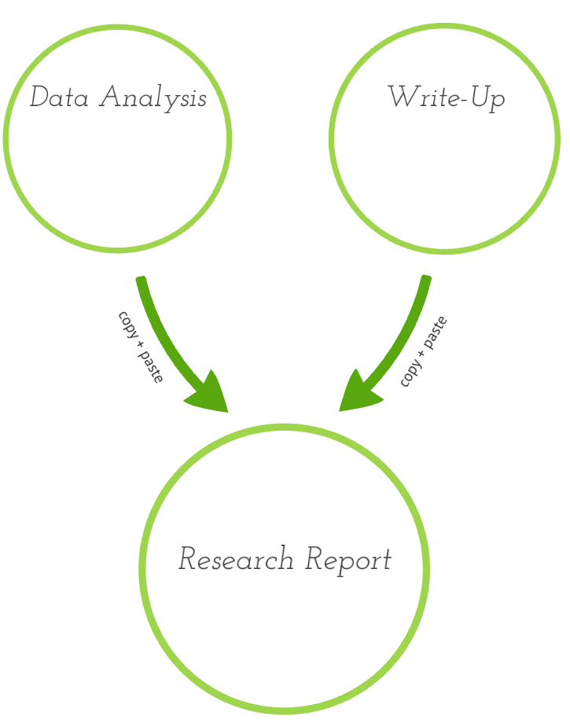

Courtesy of Bray, 2016

Good

- familiar format, e.g. Word
- easy learning curve

Bad

- tough for reproducibility
- difficult to update
- mistakes crop up
- teams can't collaborate easily

Ugly?

- Word/GDocs = Ugly?

## R Markdown Report/Notebook?

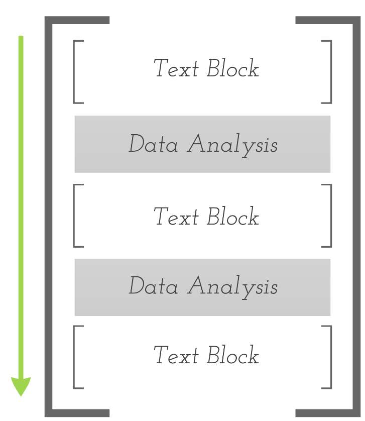

Courtesy of Bray, 2016

Good

- easy to reproduce
- easy to edit/update
- easy to collaborate
- standardized & fast

Bad

- students must learn syntax
- error-free to compile

Ugly?

- inequality in student backgrounds

## Text Formatting

```
# Header 1

## Header 2

### Header 3

This is normal sized text used in the body of our work.

For bullet points, we use dashes, e.g.

- Intro to RStudio
- More content
  - a sub-point
- Back to the original level
```

## Document Types

R Markdown can produce a variety of document types (other than the default `html` page):

- `pdf_document` makes a PDF with LaTeX (`.pdf`)
- `word_document` for Microsoft Word documents (`.docx`).
- `odt_document` for OpenDocument Text documents (`.odt`).
- `rtf_document` for Rich Text Format documents (`.rtf`)

And others.

## Presentation Types

R Markdown can also be re-purposed to produce a presentation file (as with this presentation):

- `io_slides` opens in your browser and interactive (`.html`)
- `slidy` another browser based presentation format (`.html`)
- `beamer` makes a PDF with LaTeX (`.pdf`)

## Data work

Think about data analysis as falling into three loose categories:

- management & wrangling
- visualization & summary statistics
- modeling & inference

All of this occurs in the code "chunk"

## Code chunks

- To open a code chunk hit CMD + OPTION + I on a Mac
- Or type out three backticks ``` folowed by {r}
- And then three more back ticks ``` on another line.
- Within the {r} you can specify options, like {eval = FALSE} if you don't want it to evaluate the code
- Or you can label the code chunk, e.g. {r cars} labels the chunk "cars" in your ToC

## Code Chunk: Example

````markdown
```{r cars, echo = TRUE}
summary(cars)
```
````

The option `echo = TRUE` means that the code gets included in the rendered html.

```r
summary(cars)
```

```
##      speed           dist
##  Min.   : 4.0   Min.   :  2.00
##  1st Qu.:12.0   1st Qu.: 26.00
##  Median :15.0   Median : 36.00
##  Mean   :15.4   Mean   : 42.98
##  3rd Qu.:19.0   3rd Qu.: 56.00
##  Max.   :25.0   Max.   :120.00
```

## Cases: Swoboda

Econometrics

- Basics of slides w/ math & models w/o teaching to students (yet; coming soon!)

Senior Seminar in Environmental Economics

- 15 Students w/ reproducible final project
- Reproduce work in published papers with 'problems' as pedagogy (what happens if you need to update your data?)
- Create custom progress reports for students

Micro

- Interactive shiny apps for students

## Cases: Halliday

Behavioral Economics

- 20 - 35 Students (taught twice)
- Slides, notes and assignments in Rmd & html
- Students do a reproducible research project in teams
- Mid-term in Rmd & final project in Rmd
- Fully reproduced work in 3/5; partially in 2/5
- Mid-way through second time

Special Studies

- Reproducible project on job satisfaction, voice, autonomy
- Reproducible project on Alaska permanent fund and welfare

## Cases: Dvorak

Business Analytics

- 25 - 35 Students; upper-level
- 3 main outcomes
- ability to manipulate data
- ability to analyze data
- the ability to formulate questions that can be answered using data
- use train & test regimen from data science and machine learning
- Homework & exams in Rmd; simulate 'real world' with access to internet & notes
- Students perform better in senior theses

Honors theses

- See what Michael says about theses; similar ideas apply

## Take-home messages

- **Free:** Because Rmd package suite is free, students can use on own laptops or access R Studio Server (efficiency in costs)
- **On Demand**: Free => on demand; over break; weekends; dorm room (massive issue with Stata/SPSS)
- **Workflow & suite**: Everything in one place & exportable to different outputs (package suite & workflow efficiency)
- **Reproducibility**: Enables reproducible work through R Studio & Rmd basics, helped by coaching file structure & documentation (efficiency in workflow)

## Counters?

1. "R and R Markdown are open source and do not have the interests of private, profit-maximizing firms at their core; they will therefore be nec- essarily inferior to Stata, SAS and private sector alternatives."
2. "Stata has released dyndoc, so I don't need to learn RMarkdown."
3. "I cannot get the equivalent of [Command X] that I use in [Statistical Package Y]. *I* can't work without [Command X]."
4. "I don't know R and there is a fixed cost to switching. It is irrational for me to incur that cost without subsidization from [my department/college/profession]."
5. "This might work in small classes, but not in my 100-student class."

## What else?

R Markdown and R Studio together have excellent capabilities.

- R Studio can show you the output of the commands *within* the R Markdown file
- R Studio has *error-detection* and *debugging* assistance for your code (unlike, e.g. STATA or aspects of Excel)
- R Studio server can be hosted online and your students work with logins there

## Lessons from experience

Michael:

Students will only learn commands through graded assignments

Aaron:

Students can struggle with basic computing (working directory, etc.)

## Lessons from Simon

Students have to adjust to getting the Basics Right

- file paths
- script vs. markdown
- source vs. output

Students know WYSIWYG

- MS Word & G docs are WYSIWYG, but Rmd is not.

Installing packages

- analogy: you have to install apps (packages) to do different things on your (RStudio & R)
- Chrome extensions
- R Studio Server = GOOD & free

## Conclusion

- Adopting R Markdown \(\uparrow\) classroom efficiency
- Tradeoffs? Content coverage?
- Externalities? Greater success in later courses/theses
- Students more data literate
- Integrity & economic research w/ reproducibility

## R & Rmd Link Love?

New to R?

- Check out the Computation and Visualization Consortium's week-long [workshop](https://www.macalester.edu/hhmi/curricularinnovation/cvc/) each summer
- Consider subscribing to classes at [Datacamp.com](http://www.datacamp.com) (take the intro free of charge)
- Grolemund & Wickham, 2016, *R for Data Science*, [r4ds](http://r4ds.had.co.nz)
- Baumer, Horton & Kaplan, forthcoming, [*Modern Data Science with R*](https://www.crcpress.com/Modern-Data-Science-with-R/Baumer-Kaplan-Horton/p/book/9781498724487).

## Slide with Plot (Reproduction of Sutter, 2009)

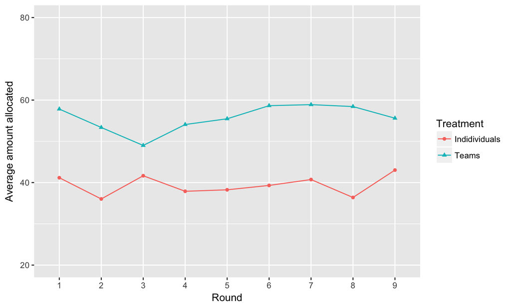

## Dynamic Graphs

[interactive chart not shown]

## Plotly Graphs

[interactive chart not shown]

## Alter and check some data

```
##   session subject  r1  r2  r3  r4  r5  r6  r7  r8  r9  treatment team
## 1       1       1   0   0   0   0  10  10   0   0   0 individual   NA
## 2       1       2   0   0  30  40  40   0   0   0  20 individual   NA
## 3       1       3  30  30   0   0   0  60  60  10   0 individual   NA
## 4       1       4  20   0 100   0   0  30  75 100 100 individual   NA
## 5       1       5 100 100 100 100 100 100 100 100 100 individual   NA
## 6       1       6 100 100 100 100 100 100 100   0   0 individual   NA
##           uniqid
## 1 1_individual_1
## 2 1_individual_2
## 3 1_individual_3
## 4 1_individual_4
## 5 1_individual_5
## 6 1_individual_6
```

## Statistical Tests

```
##
##  Wilcoxon rank sum test with continuity correction
##
## data:  value by treatment
## W = 52876, p-value = 3.838e-10
## alternative hypothesis: true location shift is not equal to 0
```

## Regression output

```
##
## Call:
## lm(formula = value ~ treatment, data = SutNarrow)
##
## Residuals:
##     Min      1Q  Median      3Q     Max
## -61.370 -29.385  -0.542  38.630  60.615
##
## Coefficients:
##                    Estimate Std. Error t value Pr(>|t|)
## (Intercept)          39.385      1.451  27.152  < 2e-16 ***
## treatmentmessage     21.985      1.994  11.028  < 2e-16 ***
## treatmentmixed       10.609      1.925   5.510 3.92e-08 ***
## treatmentpaycomm     10.886      2.144   5.077 4.09e-07 ***
## treatmentteamtreat   16.313      2.629   6.204 6.34e-10 ***
## ---
## Signif. codes:  0 '***' 0.001 '**' 0.01 '*' 0.05 '.' 0.1 ' ' 1
##
## Residual standard error: 34.81 on 2713 degrees of freedom
## Multiple R-squared:  0.04473,    Adjusted R-squared:  0.04333
## F-statistic: 31.76 on 4 and 2713 DF,  p-value: < 2.2e-16
```

## Or a Panel Regression

```
## Oneway (time) effect Random Effect Model
##    (Swamy-Arora's transformation)
##
## Call:
## plm(formula = value ~ treatment, data = SutNarrow, effect = "time",
##     model = "random", index = c("uniqid"))
##
## Balanced Panel: n=302, T=9, N=2718
##
## Effects:
##                    var  std.dev share
## idiosyncratic 1197.631   34.607 0.985
## time            18.044    4.248 0.015
## theta:  0.5755
##
## Residuals :
##     Min.  1st Qu.   Median  3rd Qu.     Max.
## -61.9533 -28.6148  -2.6745  33.8010  64.4377
##
## Coefficients :
##                    Estimate Std. Error t-value  Pr(>|t|)
## (Intercept)         39.3854     2.0207 19.4914 < 2.2e-16 ***
## treatmentmessage    21.9850     1.9815 11.0951 < 2.2e-16 ***
## treatmentmixed      10.6093     1.9137  5.5437 3.246e-08 ***
## treatmentpaycomm    10.8862     2.1313  5.1079 3.484e-07 ***
## treatmentteamtreat  16.3130     2.6134  6.2420 4.996e-10 ***
## ---
## Signif. codes:  0 '***' 0.001 '**' 0.01 '*' 0.05 '.' 0.1 ' ' 1
##
## Total Sum of Squares:    3402300
## Residual Sum of Squares: 3248300
## R-Squared:      0.045255
## Adj. R-Squared: 0.043848
## F-statistic: 32.1494 on 4 and 2713 DF, p-value: < 2.22e-16
```

## Even Fancy Regression Output

|  | *Dependent variable:* |
| --- | --- |
|  | value |
| treatmentmessage | 21.985*** |
|  | (1.994) |
| treatmentmixed | 10.609*** |
|  | (1.925) |
| treatmentpaycomm | 10.886*** |
|  | (2.144) |
| treatmentteamtreat | 16.313*** |
|  | (2.629) |
| Constant | 39.385*** |
|  | (1.451) |
| Observations | 2,718 |
| R<sup>2</sup> | 0.045 |

## Math?

R Markdown uses \(\LaTeX\) for math and it immediately gets displayed in R Studio.

That is, \(\LaTeX\) without the challenges of learning the packages, tables, etc that makes learning \(\LaTeX\) so hard.

In-line equations are bracketed by single dollar signs `$`.

Off-set equations are bracketed by double dollar signs `$$`.